# Laboratory 5: Statical Methods for Data Science

Bootstrap and Bayesian Inference

N Torelli, G Di Credico, V Gioia

28 November 2022

# Bootstrap

Bootstrap is an inferential technique based on computational aspects, allowing to carry out inferential results by using simulations. The underlying idea is to **evaluate a property of an estimator or a statistical procedure** by means of a **resampling of the observed sample**.

Let $\mathbb{x} = (x_1, \ldots, x_n)$ be a sample from an unknown ${\rm F}$, and $\hat \theta(\mathbb{x})$ be an estimate of a parameter of the population, $\theta$. Having other samples of size $n$ from the population, we can have other estimate of $\theta$ and we can compute the variance of estimator $var_{\rm F}(\hat \theta(\boldsymbol{X} ))$ by using the sample variance of such estimates. **But we have only one sample!!!**

The idea of the bootstrap is to emulate the process of having other samples, or in other words to resampling from the population, by resampling the original sample. Such **bootstrap samples** are random samples.

The $var_{\rm F}(\hat \theta(\boldsymbol{X}))$ can be estimated by the variance of the bootstrap distribution. However, we simulate samples from the bootstrap distribution and we estimate the bootstrap variance by using the bootstrap sample variance.

The idea is to replace the unknown ${\rm F}$ with $\rm {\hat F}$, an estimate based on the observed sample, for instance the empirical cumulative distribution function (ecdf) if we didn’t do parametric assumption on ${\rm F}$

$$\rm {\hat F (x)} = \frac{1}{n}\sum_{i=1}^{n}\mathbb{I}(x_i < x)$$

where the ecdf gives probability $1/n$ to each observation in the sample. Then, sampling from $\rm {\hat F}$ corresponds to extract random sample from the observed sample.

Then, $var_{\rm F}(\hat \theta(\boldsymbol{X}))$ is estimated by $var_{\rm {\hat F}}(\hat \theta(\boldsymbol{X}))$. The latter is difficult to be found in a closed form, reason for which we simulate from $\rm {\hat F}$.

**Algorithm**

- Simulate $\tilde {\mathbb{x}}^j$, $j=1, \ldots, R$ of size $n$ from $\hat F$
- Compute the $\hat \theta ( {\tilde {\mathbb{x}}}^j)$, $j=1, \ldots, R$
- Then estimate the boostrap variance with the sample variance

## Example

Here, we will see a basic use of the **R** function **boot**(). We will use the **bigcity** dataset, where the two columns denotes the population (in 1000’s) of 49 U.S. cities in 1920 and 1930. The 49 cities are a random sample taken from the 196 largest cities in 1920.

```r
library(boot)
data(bigcity)
head(bigcity)
```

```
##     u   x
## 1 138 143
## 2  93 104
## 3  61  69
## 4 179 260
## 5  48  75
## 6  37  63
```

Here we consider as parameter $\theta = \frac{E(X)}{E(U)}$. Such parameter could be used to estimate the total USA population in the 1930, knowing the total popuulation in the 1930. So a natural estimator is
$$\hat \theta = \frac{\overline X}{\overline Y}$$
and the estimate is given by

```r
mean(bigcity$x)/mean(bigcity$u)
```

```
## [1] 1.239019
```

To use the bootstrap, first of all we need a function to compute the estimate to provide to the **boot**() function along with the data and the number of bootstrap samples

```r
theta <- function(data,i){
mean(data[i,2])/mean(data[i,1])
}
bigcity.boot <- boot(bigcity,theta,R=1000)
```

Then, from the output we can see the estimate on the original sample, the bias and the standard error of $\hat \theta$

```r
bigcity.boot
```

```
##
## ORDINARY NONPARAMETRIC BOOTSTRAP
##
##
## Call:
## boot(data = bigcity, statistic = theta, R = 1000)
##
##
## Bootstrap Statistics :
##     original      bias    std. error
## t1* 1.239019 0.002415218   0.0366372
```

```r
bigcity.boot$t0
```

```
## [1] 1.239019
```

```r
bias <- mean(bigcity.boot$t) - bigcity.boot$t0

sd(bigcity.boot$t)
```

```
## [1] 0.0366372
```

Also, we can visualize the distribution of the bootstrap estimates

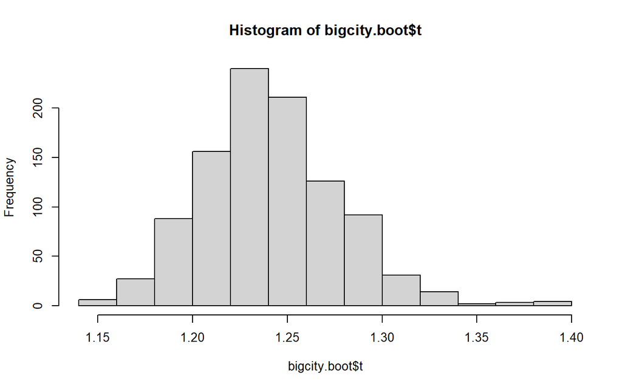

```r
hist(bigcity.boot$t)
```

At this point, it is possible to obtain a confidence interval with level 0.95 for $\theta$ via

```r
boot.ci(bigcity.boot)
```

```
## BOOTSTRAP CONFIDENCE INTERVAL CALCULATIONS
## Based on 1000 bootstrap replicates
##
## CALL :
## boot.ci(boot.out = bigcity.boot)
##
## Intervals :
## Level      Normal              Basic
## 95%   ( 1.165,  1.308 )   ( 1.159,  1.302 )
##
## Level     Percentile            BCa
## 95%   ( 1.176,  1.319 )   ( 1.179,  1.324 )
## Calculations and Intervals on Original Scale
```

We will see the

- standard approximate Wald-type $(1- \alpha)\%$ confidence interval (**normal**) $\hat \theta \pm z_{1-\alpha/2} \hat {SE}_{boot} (\hat \theta)$

However, the **boot.ci**() function provide such interval after correcting by the bias, as you can see.

```r
boot.ci(bigcity.boot, type="norm")$normal
```

```
##      conf
## [1,] 0.95 1.164796 1.308411
```

```r
bigcity.boot$t0  + c(-1, 1) * qnorm(0.975) * sd(bigcity.boot$t)
```

```
## [1] 1.167211 1.310826
```

```r
# Correcting by bias
bigcity.boot$t0- bias  + c(-1, 1) * qnorm(0.975) * sd(bigcity.boot$t)
```

```
## [1] 1.164796 1.308411
```

- basic bootstrap confidence interval (**basic**)
  $$(2 \hat \theta - q^*_{1-\alpha/2},2 \hat \theta - q^*_{\alpha/2})$$
- percentile - the quantiles of the bootstrap distribution (**perc**)

  $(\hat \theta^*_{\alpha/2}, \hat \theta^*_{1-\alpha/2})$

```r
boot.ci(bigcity.boot, type="basic")$basic[c(4,5)]
```

```
## [1] 1.159257 1.301758
```

```r
(2 * bigcity.boot$t0) -quantile(bigcity.boot$t, prob=c(0.975, 0.025))
```

```
##    97.5%     2.5%
## 1.159956 1.301023
```

```r
boot.ci(bigcity.boot, type="perc")$perc[c(4,5)]
```

```
## [1] 1.176279 1.318780
```

```r
quantile(bigcity.boot$t, prob=c(0.025, 0.975))
```

```
##     2.5%    97.5%
## 1.177014 1.318081
```

**Something wrong?!** The slight differences are due to a different function to compute the quantiles which is build internally in the **boot**, but probably it is simply the type = 6 way to compute the quantiles with **quantile**() function.

```r
# BASIC
(2 * bigcity.boot$t0 - boot:::norm.inter(bigcity.boot$t, alpha=c(0.975, 0.025)))[,2]
```

```
## [1] 1.159257 1.301758
```

```r
2 * bigcity.boot$t0 -quantile(bigcity.boot$t, prob=c(0.975, 0.025), type=6)
```

```
##    97.5%     2.5%
## 1.159257 1.301758
```

```r
# PERCENTILE
boot:::norm.inter(bigcity.boot$t, alpha=c(0.025,0.975))[,2]
```

```
## [1] 1.176279 1.318780
```

```r
quantile(bigcity.boot$t, prob=c(0.025, 0.975), type = 6)
```

```
##     2.5%    97.5%
## 1.176279 1.318781
```

**It’s your turn** Write by hand an **R** function to perform a bootstrap and consider the same example used above. Such function takes in input the data, the number of bootstrap replications, (a function for) the statistic of interest and the confidence level; the output must be a list containing the estimate, the bootstrap estimates, the estimated bias and standard error, as well the normal, basic and percentile confidence intervals.

```r
our_bootstrap <- function(data,R=1000,theta, conf=0.95){
  out <- list()

  datab <- matrix(sample(1:nrow(data),size=nrow(data)*R,replace=TRUE),nrow=R)
  estb <- apply(datab,1,theta,data)
  est <- theta(1:nrow(data),data)
  out$est <- est
  out$distn <- estb
  out$bias <- mean(estb)-est
  out$se <- sd(estb)
  out$basic <- (2 * est) - quantile(estb, prob=(1+c(1,-1)*conf)/2, type=6)

  out$norm <- est -  out$bias  + c(-1, 1) * qnorm((1+conf)/2) * sd(estb)

  out$perc <- quantile(estb, prob=(1+c(-1,1)*conf)/2, type = 6)
  attr(out$basic, "names") <- attr(out$norm, "names") <- attr(out$perc, "names") <- c(paste0(as.character(100*(1-conf)/2),"%"),paste0(as.character(100*(1+conf)/2),"%"))
  out
}

theta1 <- function(i,data){
  mean(data[i,2])/mean(data[i,1])
}

bigcity.boot <- our_bootstrap(bigcity,theta=theta1)
```

# Bayesian statistics

Let $\boldsymbol y=(y_1, \ldots, y_n)$ be the data from $f(\boldsymbol y | \theta)$.

The likelihood inference is based on $L(\theta)=f(\boldsymbol y | \theta)$, whose direct maximisation gives the MLE of $\theta$. But $L(\theta)$ could be not considered as probability for $\theta$ ($\theta$ is a parameter).

Bayesian inference deal $\theta$ as a random variable, having a distribution $\pi (\theta)$ and the inference is based on obtaining $\pi(\theta| \boldsymbol y)$,

$$\pi(\theta| \boldsymbol y) = \frac{f(\boldsymbol y | \theta) \pi(\theta)}{\int_{\Theta} f(\boldsymbol y | \theta) \pi(\theta) d\theta}$$

Then

- $\pi(\theta| \boldsymbol y)$ contains all the information useful for inferential purposes
- Every aspect of the Bayesian inference has an interpretation in terms of probability (confidence intervals are replaced by credibility intervals $P(\theta \in (c_1, c_2) | \boldsymbol y) = 1- \alpha$ )

Although Bayesian inference appears before Likelihood inference chronologically, its use become massive in the last decades. The reason is mainly related to computational aspects, due to the difficulties related to the computation of $\int_{\Theta} f(\boldsymbol y | \theta) \pi(\theta) d\theta$. A part in the conjugate case, such integral is obtained by using asymptotic approximation, numerical integration and MCMC.

## Normal case with $\sigma^2$ known

Suppose $y_1, \ldots, y_n \sim \mathcal{N}(\theta, \sigma^{2})$, with $\sigma^{2}$ known. The log-likelihood, up to an additive constant, is:

$$l(\theta; y) = -\frac{1}{2\sigma^{2}}\sum_{i=1}^{n}(y_i-\theta)^2.$$
If we frame our analysis in **Bayesian** inference, this log-likelihood has not to be maximized over, in order to retrieve its maximum (MLE); rather, the log-likelihood is just a quantity connected to the experiment (observation), framed in a broader context where we still need to incorporate a pre-experimental prior belief about $\theta$: technically, a **prior** distribution. Several prior choices are allowed, and the literature about the prior choice is still growing.

## Conjugate prior

The simplest way in this case is to assume a normal prior:

$$\theta \sim \pi(\theta) =\mathcal{N}(\mu, \tau^{2}),$$
with fixed *hyperparameters* $\mu$ and $\tau^2$. In such a case, according to the Bayes theorem our posterior distribution is:

$$\pi(\theta|y) \propto \pi(\theta)L(\theta;y)\propto \mathcal{N}(\mu^{*}, \tau^{*2}),$$

where:

$$\begin{align}
\begin{split}
\mu^{*}= & \frac{\frac{n}{\sigma^{2}}\bar{y}+\frac{1}{\tau^{2}}\mu }{\frac{n}{\sigma^{2}}+\frac{1}{\tau^2}}\\
\tau^{*2}= & \left(\frac{n}{\sigma^{2}}+\frac{1}{\tau^2}\right)^{-1}
\end{split}
\label{eq:posterior_values}
\end{align}$$

```r
#Input values
theta <- 2 #True mean
sigma2 <- 2 # variance considered known
n <- 10 #Sample size
mu <- 7 #Prior mean
tau2 <- 2 #Prior variance


#Data generation
set.seed(123)
y <- rnorm(n,theta, sqrt(sigma2))

#Posterior mean
mu_star <- ((1/tau2)*mu+(n/sigma2)*mean(y))/( (1/tau2)+(n/sigma2))
mu_star
```

```
## [1] 2.550488
```

```r
#Posterior standard deviation
sd_star <- sqrt(1/( (1/tau2)+(n/sigma2)))
sd_star
```

```
## [1] 0.4264014
```

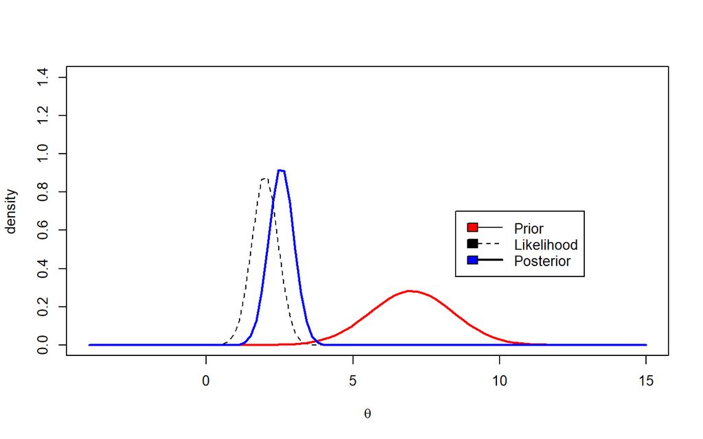

```r
# Plot of likelihood, prior and posterior distribution
curve(dnorm(x, theta, sqrt(sigma2/n)),xlim=c(-4,15), lty=2, lwd=1, col="black", ylim=c(0,1.4),
ylab="density", xlab=expression(theta))

curve(dnorm(x, mu, sqrt(tau2) ), xlim=c(-4,15), col="red", lty=1,lwd=2,  add =T)
curve(dnorm(x, mu_star, sd_star),
  xlab=expression(theta), ylab="", col="blue", lwd=2, add=T)
legend(8.5, 0.7, c("Prior", "Likelihood", "Posterior"),
  c("red", "black", "blue", "grey" ), lty=c(1,2,1),lwd=c(1,1,2), cex=1)
```

$\mu^{*}$ is a weighted mean of the MLE $\bar{y}$ and the prior mean $\mu$. Hence, by increasing either the prior variance $\tau^2$ or the sample size $n$, our posterior will tend to the likelihood, and the posterior mean will approximately coincide with the MLE $\bar{y}$.

In such a case, we may obtain a **closed** form for the posterior distribution, *which is still a normal distribution with updates parameters*. This issue is well known as **conjugacy**: the prior and the posterior distributions belong to the same parametric family. However, in the majority of the cases the conjugacy is not guaranteed, since the priors we are going to choose do not belong to the same distribution family of the posterior.

For all these cases, a closed form is not obtained, and we require **simulation methods**, such as **Markov Chain Monte Carlo** methods. According to these procedures, the posterior distribution is approximately described by a sequence of random draws, a Markov chain.

Several softwares have been developed in these years for these purposes, and this growing *work in progress* made the Bayesian inference a sort of milestone for computational scientists. For illustration purposes, we will use here the $\mathsf{Stan}$ software, which relies on an extension of MCMC (Hamiltonian Monte Carlo sampling), to compute the posterior distribution via simulation.

```r
library(rstan)
#launch Stan model:
# Data specification
data<- list(N=n, y=y, sigma =sqrt(sigma2), mu = mu, tau = sqrt(tau2))

# Fit a Stan model
fit <- stan(file="normal.stan", data = data, chains = 4, iter=2000)
```

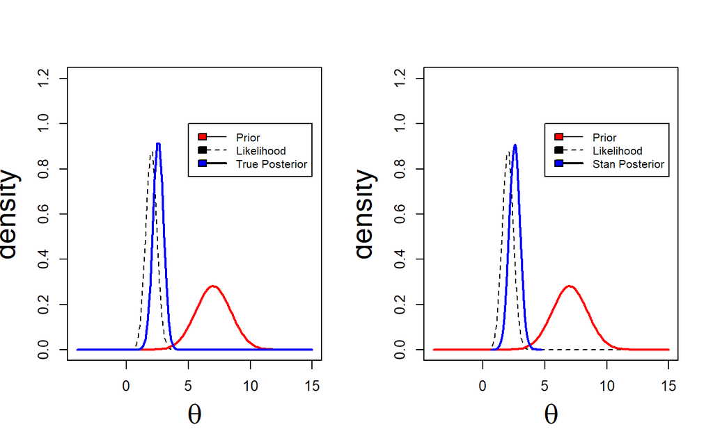

```r
#extract Stan output
sim <- extract(fit)

#draw the true analytical posterior and the Stan simulated posterior
par(mfrow=c(1,2))
curve(dnorm(x, theta, sqrt(sigma2/n)),xlim=c(-4,15), lty=2, lwd=1, col="black", ylim=c(0,1.2),
  ylab="density", xlab=expression(theta), cex.lab=2)

curve(dnorm(x, mu, sqrt(tau2) ), xlim=c(-4,15), col="red", lty=1,lwd=2,  add =T)
curve(dnorm(x, mu_star, sd_star),
  xlab=expression(theta), ylab="", col="blue", lwd=2,
  cex.lab=2, add=T)

legend(5, 1, c("Prior", "Likelihood", "True Posterior"),
  c("red", "black", "blue", "blue" ), lty=c(1,2,1),lwd=c(1,1,2), cex=0.8)


curve(dnorm(x, theta, sqrt(sigma2/n)),xlim=c(-4,15), lty=2, lwd=1, col="black", ylim=c(0,1.2),
  ylab="density", xlab=expression(theta), cex.lab=2)
curve(dnorm(x, mu, sqrt(tau2) ), xlim=c(-4,15), col="red", lty=1,lwd=2,  add =T)
lines(density(sim$theta, adj=2), col ="blue", lwd=2, lty =1)
legend(5, 1, c("Prior", "Likelihood", "Stan Posterior"),
  c("red", "black", "blue", "blue" ), lty=c(1,2,1),lwd=c(1,1,2), cex=0.8)
```

As may be seen, the two posteriors quite coincide. In this simple case, performing MCMC does not provide any benefit over the analytical computations. But if we move away from the *comfortable* case for the couple prior-likelihood, as for the normal-normal example, MCMC becomes essential.

## Non-conjugate priors

Let’s change the assumption of the model above, and consider now a uniform prior for $\theta$:

$$\theta \sim \mathsf{Unif}(-10,10).$$

If we compute the numerator of the Bayes theorem we obtain:

$$\pi(\theta|y) \propto L(\theta;y)\pi(\theta)=\frac{1}{\sqrt{2\pi\sigma^2}}e^{-\frac{1}{2\sigma^2}\sum_{i}(y_i-\theta)^2}\mbox{I}_{[-10,10]}(\theta),$$

where $\mbox{I}_{[-10,10]}(\theta)$ is the usual event indicator for the Uniform distribution, equals 1 if $\theta \in[-10,10]$, and 0 otherwise. This product is not proportional to any known distribution, and in such a case we need simulation.

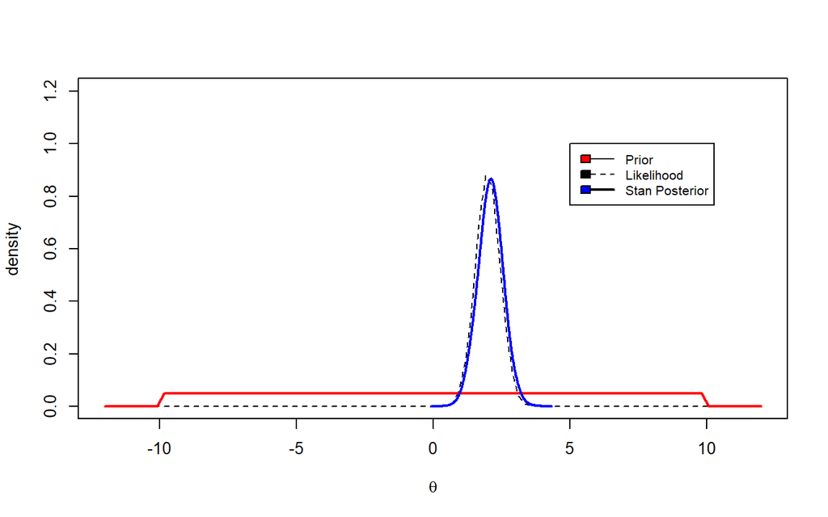

```r
#launch Stan model with the uniform prior in place of normal prior

data2<- list(N=n, y=y, sigma =sqrt(sigma2), a=-10, b=10)
fit2 <- stan(file="normal_uniform.stan", data = data2, chains = 4, iter=2000,
  refresh=-1)

#extract the Stan output
sim2 <- extract(fit2)

#plot the Stan posterior

curve(dnorm(x, theta, sqrt(sigma2/n)),xlim=c(-12,12), lty=2, lwd=1, col="black", ylim=c(0,1.2),
  ylab="density", xlab=expression(theta))
curve(dunif(x, -10,10  ), xlim=c(-12,12), col="red", lty=1,lwd=2,  add =T)
lines(density(sim2$theta, adj=2), col ="blue", lwd=2, lty =1)
legend(5, 1, c("Prior", "Likelihood", "Stan Posterior"),
  c("red", "black", "blue", "blue" ), lty=c(1,2,1),lwd=c(1,1,2), cex=0.8)
```

Of course, we may control the variance of the Uniform prior $\mathsf{Unif}(a,b)$, amounting at $\frac{1}{12}(b-a)^{2}$, and consequently the posterior distribution.

**Exercise** Suppose you receive $n = 15$ phone calls in a day, and you want to build a model to assess their average length. Your likelihood for each call length is $y_i \sim \mathsf{Exponential}(\lambda)$. Now, you have to choose the prior $\pi(\lambda)$. Please, tell which of these priors is adequate to describe the problem, and provide a short motivation for each of them:

1. $\pi(\lambda)= \mathsf{Beta}(4,2)$;
2. $\pi(\lambda)= \mathsf{Normal}(1,2)$;
3. $\pi(\lambda)=\mathsf{Gamma}(4,2)$;

Now, compute your posterior as $\pi(\lambda|y)\propto L(\lambda;y)\pi(\lambda)$ for the selected prior. If your first choice was correct, you will be able to compute it analitically.

## MCMC world

Inspecting the posterior distribution via simulation according to some Markov Chains draws sounds like magic. Actually, there are strong theorems and complicate statements behind this fancy result. In the example above, we retrieved the posterior distribution for $\theta$ via $\mathsf{Stan}$ software. But how can visualize these values? For an exhaustive handling, consult the vignettes of **rstan**, **rstanarm** and **bayesplot** accessible from https://mc-stan.org/rstan/.

This could be done by using the **traceplot** function; we will as point estimate the posterior mean

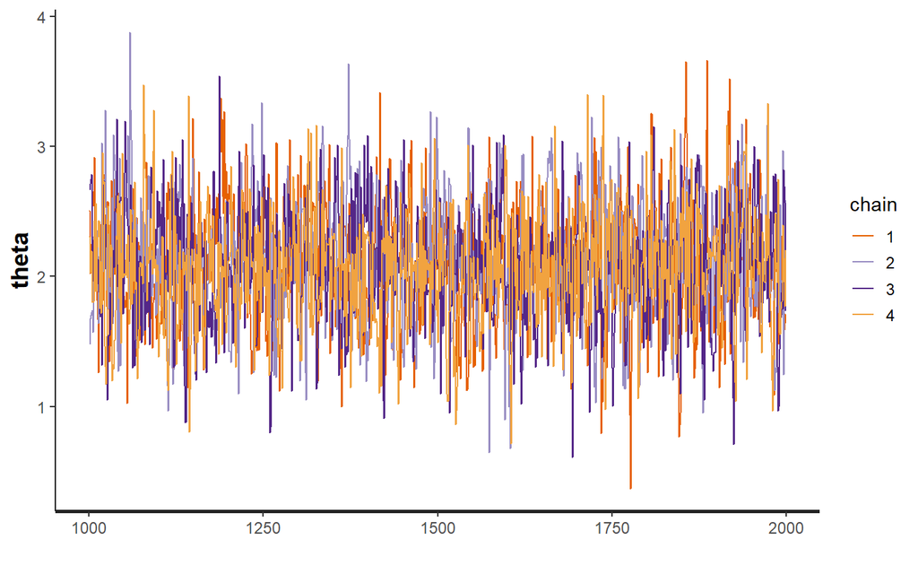

```r
#traceplot
traceplot(fit2, pars ="theta")
```

```r
theta_est <- mean(sim2$theta)
theta_est
```

```
## [1] 2.101034
```

In this case, running a bunch of chains until they converge to a **stationary distribution** is the usual way.

We can obtain also some MCMC areas:

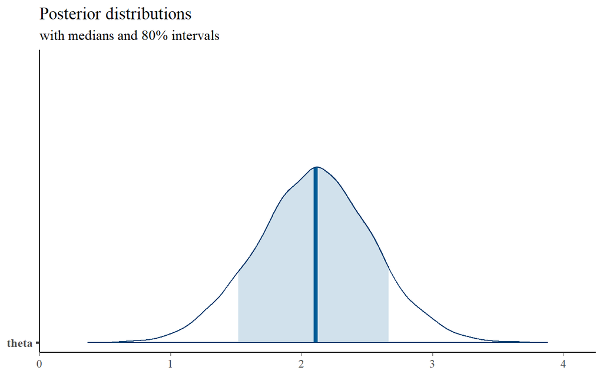

```r
library("bayesplot")
library("rstanarm")
library("ggplot2")

#MCMC areas
posterior <- as.matrix(fit2)

mcmc_areas(posterior,
           pars = "theta",
           prob = 0.8) +
 labs(
   title = "Posterior distributions",
   subtitle = "with medians and 80% intervals"
 )
```

```r
fit2
```

```
## Inference for Stan model: normal_uniform.
## 4 chains, each with iter=2000; warmup=1000; thin=1;
## post-warmup draws per chain=1000, total post-warmup draws=4000.
##
##         mean se_mean   sd   2.5%    25%    50%    75%  97.5% n_eff Rhat
## theta   2.10    0.01 0.45   1.22   1.81   2.11   2.40   2.97  1619    1
## lp__  -20.24    0.02 0.73 -22.22 -20.38 -19.96 -19.79 -19.74  1912    1
##
## Samples were drawn using NUTS(diag_e) at Mon Nov 28 17:53:12 2022.
## For each parameter, n_eff is a crude measure of effective sample size,
## and Rhat is the potential scale reduction factor on split chains (at
## convergence, Rhat=1).
```

If the variance $\sigma^2$ of our assumed model above is not known in advance, our model above is **biparametric**. Let’s then extend the model above, and consider $\sigma^{2}$ as unknown:

$$\begin{align*}
y_{1},\ldots,y_{n} & \sim \mathcal{N}(\theta, \sigma^2)\\
\theta &\sim \mathsf{Unif}(-10,10)\\
{\sigma} &\sim \mathsf{Cauchy^{+}}(0, 2.5),
\end{align*}$$

where $\mathsf{Cauchy^{+}}(0, 2.5)$ denotes an Half-Cauchy with location 0 and scale 2.5.

```r
#launch biparametric Stan model
data3<- list(N=n, y=y, a=-10, b=10)
fit3 <- stan(file="biparametric.stan", data = data3, chains = 4, iter=2000,
  refresh=-1)
#extract stan output for biparametric model
sim3 <- extract(fit3)
posterior_biv <- as.matrix(fit3)
```

Here, we see the posterior summaries as well the traceplot

```r
theta_est <- mean(sim3$theta)
sigma_est <- mean(sim3$sigma)
c(theta_est, sigma_est)
```

```
## [1] 2.111352 1.508981
```

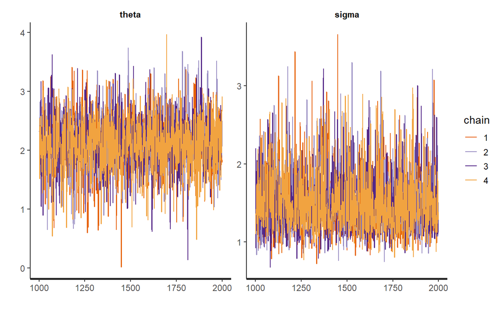

```r
traceplot(fit3, pars=c("theta", "sigma"))
```

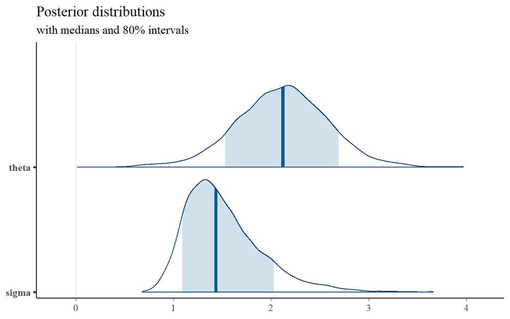

```r
mcmc_areas(posterior_biv,
           pars = c("theta","sigma"),
           prob = 0.8) +  labs(
   title = "Posterior distributions",
   subtitle = "with medians and 80% intervals"
 )
```

```r
fit3
```

```
## Inference for Stan model: biparametric.
## 4 chains, each with iter=2000; warmup=1000; thin=1;
## post-warmup draws per chain=1000, total post-warmup draws=4000.
##
##         mean se_mean   sd   2.5%    25%    50%    75%  97.5% n_eff Rhat
## theta   2.11    0.01 0.47   1.14   1.81   2.12   2.42   3.05  1833    1
## sigma   1.51    0.01 0.39   0.94   1.23   1.44   1.71   2.47  2219    1
## lp__  -22.74    0.03 1.01 -25.41 -23.17 -22.42 -22.00 -21.71  1316    1
##
## Samples were drawn using NUTS(diag_e) at Mon Nov 28 17:54:05 2022.
## For each parameter, n_eff is a crude measure of effective sample size,
## and Rhat is the potential scale reduction factor on split chains (at
## convergence, Rhat=1).
```

**Exercise** Having installed $\mathsf{rstan}$ library, open the file model called $\mathsf{biparametric.stan}$, and replace the line:

$$\mathsf{ target+=cauchy\_lpdf(sigma| 0, 2.5);}$$

with the following one:

$$\mathsf{ target+=uniform\_lpdf(sigma| 0.1, 10);}$$

Which prior are you now assuming for your parameter $\sigma$? Reproduce the same plots as above and briefly comment.

**Extra** # Model comparisons

In Bayesian inference we can still perform some tests in order to verify some assumptions. Rather than verifying a particular value for a parameter, we are here more interested in assessing some model comparisons in term of prior choices. Suppose you want to test the hypothesis

$$H_0: \theta \in \Theta_0; H_1: \theta \in \Theta_1,$$

where $\Theta_0$ and $\Theta_1$ form a partition of the parameter space.

The beliefs about the two hypotheses are summarized by the posterior odds ratio:

$$\frac{p_0}{p_1}=\frac{P(\theta\in \Theta_0|y)}{P(\theta\in \Theta_1|y)}=\frac{\int_{\Theta_0}\pi(\theta|y)d\theta}{\int_{\Theta_1}\pi(\theta|y)d\theta}$$

A measure of the evidence provided by the data in support of $H_0$ over $H_1$ is the **Bayes factor**:

$$BF_{01}= \frac{\mbox{posterior odds}}{\mbox{prior odds}}=\frac{p_0/p_1}{\pi_0/\pi_1}=\frac{m_{0}(y)}{m_1(y)},$$

where $\pi_0$ and $\pi_1$ are respectively $\int_{\Theta_0}\pi(\theta)d\theta$ and $\int_{\Theta_1}\pi(\theta)d\theta$ the probability of the two hypotheses prior observing the data. $m_0(y)$ and $m_1(y)$, better known as *marginal likelihoods*, are $\int_{\Theta_0}L(\theta_0;y)\pi(\theta_0)d\theta_0$ and $\int_{\Theta_1}L(\theta_1;y)\pi(\theta_1)d\theta_1$ respectively.

## Models for soccer goals

Suppose we are interested in assessing the average number of goals scored by a given team in Major league Soccer, and denote the goals for $n$ games as $y_1,\ldots,y_n$. Since goals are relatively rare events, we assume that:

$$y_i \sim \mathsf{Poisson}(\lambda), \ i=1,\ldots,n,$$
thus, the likelihood is:

$$L(\lambda; y)=\prod_{i=1}^{n} e^{-\lambda}\frac{\lambda^{y_{i}}}{y_i!}.$$
Now, we have to elicit a prior for the parameter $\lambda$, and several choices are plausible:

- **Prior 1**: $\lambda \sim \mathsf{Gamma}(4.57, 1.43)$, meaning that the average is $\alpha/\beta= 3.195804$, with $\alpha$ the shape parameter and $\beta$ the rate parameter, and the quartiles for $\lambda$ are given by 2.10 and 4.04.
- **Prior 2**: $\log(\lambda) \sim \mathcal{N}(1, .5^2)$. The quartiles for this prior for $\log(\lambda)$ are 0.66 and 1.34, which translates to prior quartiles for $\lambda$ of 1.94 and 3.81.
- **Prior 3**: $\log(\lambda) \sim \mathcal{N}(2, .5^2)$. The quartiles for $\log(\lambda)$ are 1.66 and 2.33, which translates to prior quartiles for $\lambda$ of 5.25 and 10.27.
- **Prior 4**: $\log(\lambda) \sim \mathcal{N}(1, 2^2)$. The quartiles for $\log(\lambda)$ are -0.34 and 2.34, which translates to prior quartiles for $\lambda$ of 0.71 and 10.38.

The dataset $\mathsf{soccergoals}$ in the $\mathsf{LearnBayes}$ package contains the number of goals across the 35 matches of the 2006 season for a given team. Let’s write the prior functions and plot the four priors and the likelihood for $\theta=\log(\lambda)$.

The likelihood function is proportional to
$$L(\theta) \propto e^{-n\lambda} \lambda^{\sum_{i=1}^{n}y_i}$$
and we recognize the kernel of a gamma distribution.
$\Lambda \sim Ga(\alpha, \beta)$
$$f_\Lambda(\lambda) \propto \lambda^{\alpha-1} e^{-\frac{\lambda}{\beta}}$$
Then $\alpha=\sum_{i=1}^{n}y_i + 1$ and $\beta=1/n$.

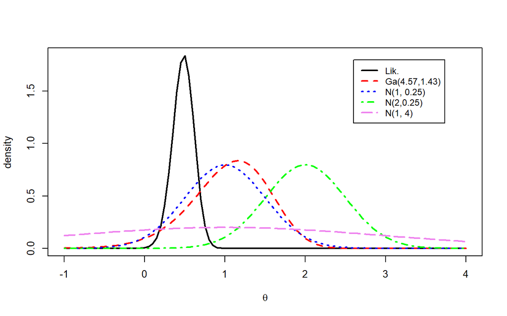

```r
library(LearnBayes)
data(soccergoals)

y <- soccergoals$goals

#write the likelihood function via the gamma distribution


lik_pois<- function(theta, data){
  n <- length(data)
  lambda <- exp(theta)
  dgamma(lambda, shape =sum(data)+1, scale=1/n)
}
# Write the prior (gamma)
 prior_gamma <- function(theta,par){
  lambda <- exp(theta)
  dgamma(lambda, par[1], rate=par[2])*lambda
}

 # Write the prior (Normal)
 prior_norm <- function(theta,npar){
 dnorm(theta, npar[1], npar[2])

}


#Plot likelihood
 curve(lik_pois(theta=x, data=y), xlim=c(-1,4), xlab=expression(theta), ylab = "density", lwd =2 )

#prior 1
 curve(prior_gamma(theta=x, par=c(4.57, 1.43)), lty =2, col="red", add = TRUE, lwd =2)

 # prior 2
 curve(prior_norm(theta=x, npar=c(1, .5)), lty =3, col="blue", add =TRUE, lwd=2)

#prior 3
 curve(prior_norm(theta=x, npar=c(2, .5)), lty =4, col="green", add =TRUE, lwd =2)

#prior 4
  curve(prior_norm(theta=x, npar=c(1, 2)), lty =5, col="violet", add =TRUE, lwd =2)
  legend(2.6, 1.8, c("Lik.", "Ga(4.57,1.43)", "N(1, 0.25)", "N(2,0.25)","N(1, 4)" ),
  lty=c(1,2,3,4,5), col=c("black", "red", "blue", "green", "violet"),lwd=2, cex=0.9)
```

Let’s quickly comment. Priors 1 and 2 almost coincide in scale and location, and they propose a mean—in log scale—around 1, which is slightly greater than the likelihood mean, $\log(\bar{\lambda})=0.49$. Prior 3 is quite extreme, and results to be in conflict with the likelihood. Prior 4 is very flat and provides no much information about the parameter $\theta$.

Now we have to compute the log-posteriors, up to an additive constant, using the reparametrization $\theta= \log(\lambda)$ and calling the previous functions:

$$\log(\pi(\theta|y)) = l(\theta;y)+log(\pi(\theta)).$$

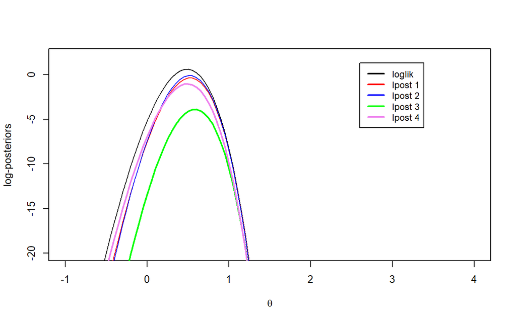

```r
# Poisson-Gamma
logpoissongamma <- function(theta, datapar){
   data <- datapar$data
   par <- datapar$par
   log_lik <- log(lik_pois(theta,data))
   log_prior <- log(prior_gamma(theta, par))
   return(log_lik+log_prior)
}

#Poisson-Normal
logpoissonnormal <- function( theta, datapar){
 data <- datapar$data
 npar <- datapar$par
 log_lik <- log(lik_pois(theta, data))
 log_prior <- log(prior_norm(theta, npar))
  return(log_lik+log_prior)
}

# Plot:
#log-likelihood
curve(log(lik_pois(y, theta=x)), xlim=c(-1,4),ylim=c(-20,2), lty =1,
   ylab="log-posteriors", xlab=expression(theta))

#log posterior 1
curve(logpoissongamma(theta=x, list(data=y, par=c(4.57, 1.43))), col="red", xlim=c(-1,4),ylim=c(-20,2), lty =1, add =TRUE)

#log posterior 2
curve(logpoissonnormal( theta=x, list(data=y, par=c(1, .5))), lty =1, col="blue",  add =TRUE)

#log posterior 3
curve(logpoissonnormal( theta=x, datapar <- list(data=y, par=c(2, .5))), lty =1, col="green", add =TRUE, lwd =2)

#log posterior 4
curve(logpoissonnormal( theta=x, datapar <- list(data=y, par=c(1, 2))), lty =1, col="violet", add =TRUE, lwd =2)


legend(2.6, 1.3, c( "loglik", "lpost 1", "lpost 2", "lpost 3", "lpost 4" ),
       lty=1, col=c("black", "red", "blue", "green", "violet"),lwd=2, cex=0.9)
```

Now we have to compute the Bayes factors. The Bayes factor in support of Prior 1 over Prior 2 is:

$$BF_{12}=\frac{m_1(y)}{m_2(y)}=\frac{\int_{\Theta_1} L(\theta_1;y)\pi(\theta_1)d\theta_1}{\int_{\Theta_2} L(\theta_2;y)\pi(\theta_2)d\theta_2}.$$

We use the function $\mathsf{laplace()}$ contained in the $\mathsf{LearnBayes}$ package for computing the posterior modes, the posterior standard deviations and the log-marginal likelihoods, $\log(m(y))$.

```r
#posterior modes, posterior standard deviations and the log-marginal likelihoods by using laplace function
datapar <- list(data=y, par=c(4.57, 1.43))
fit1 <- laplace(logpoissongamma, .5, datapar)
datapar <- list(data=y, par=c(1, .5))
fit2 <- laplace(logpoissonnormal, .5, datapar)
datapar <- list(data=y, par=c(2, .5))
fit3 <- laplace(logpoissonnormal, .5, datapar)
datapar <- list(data=y, par=c(1, 2))
fit4 <- laplace(logpoissonnormal, .5, datapar)

postmode <- c(fit1$mode, fit2$mode, fit3$mode, fit4$mode )
postsds <- sqrt(c(fit1$var, fit2$var, fit3$var, fit4$var))
logmarg <- c(fit1$int, fit2$int, fit3$int, fit4$int)
cbind(postmode, postsds, logmarg)
```

```
##       postmode   postsds   logmarg
## [1,] 0.5248047 0.1274414 -1.502977
## [2,] 0.5207825 0.1260712 -1.255171
## [3,] 0.5825195 0.1224723 -5.076316
## [4,] 0.4899414 0.1320165 -2.137216
```

Now we may compute the Bayes factors, for instance:

$$BF_{21}=m_{2}(y)/m_{1}(y)=\exp\{-1.255171+1.502877 \}= 1.281,$$
which means that Prior 2 is 1.28 times more preferable than Prior 1. This makes sense: if we look at the first plot, Prior 2 was slightly closer to the likelihood.

```r
# bayes factors
BF_matrix <- matrix(1, 4,4)
for (i in 1:3){
  for (j in 2:4){
   BF_matrix[i,j]<- exp(logmarg[i]-logmarg[j])
   BF_matrix[j,i]=(1/BF_matrix[i,j])
  }
}

round_bf <- round(BF_matrix,3)
round_bf
```

```
##       [,1]  [,2]   [,3]  [,4]
## [1,] 1.000 0.781 35.635 1.886
## [2,] 1.281 1.000 45.656 2.416
## [3,] 0.028 0.022  1.000 0.053
## [4,] 0.530 0.414 18.899 1.000
```

Every prior is favored over Prior 3, wich is the prior with the greatest likelihood conflict. Prior 2 is always favored over the other priors. Generally, the marginal probability for a prior decreases as the prior density becomes more diffuse.

**Exercise** Simulate a sample of size $n=14$ from a Bernoulli distribution parameter $p=0.5$.

- Looking at the $\mathsf{Stan}$ code for the other models, write a short $\mathsf{Stan}$ Beta-Binomial model, where $p$ has a $\mathsf{Beta}(a,b)$ prior with $a=3$, $b=3$.
- extract the posterior distribution with the function $\mathsf{extract()}$;
- produce some plots with the $\mathsf{bayesplot}$ package and comment.
- compute analitically the posterior distribution and compare it with the $\mathsf{Stan}$ distribution.